# IRF data analysis

Так можна встановити пакети

Ця функція завантажить сторонню бібліотеку (пакет) у робоче середовище

Прочитаймо дані!

| Province.State | Country.Region | Lat | Long | X1.22.2020 | X1.23.2020 | X1.24.2020 | X1.25.2020 | X1.26.2020 | X1.27.2020 | X1.28.2020 | X1.29.2020 | X1.30.2020 | X1.31.2020 | X2.1.2020 | X2.2.2020 | X2.3.2020 | X2.4.2020 | X2.5.2020 | X2.6.2020 | X2.7.2020 | X2.8.2020 | X2.9.2020 | X2.10.2020 | X2.11.2020 | X2.12.2020 | X2.13.2020 | X2.14.2020 | X2.15.2020 | X2.16.2020 | … |
| --- | --- | --- | --- | --- | --- | --- | --- | --- | --- | --- | --- | --- | --- | --- | --- | --- | --- | --- | --- | --- | --- | --- | --- | --- | --- | --- | --- | --- | --- | --- |
| Anhui | Mainland China | 31.82571 | 117.22640 | 1 | 9 | 15 | 39 | 60 | 70 | 106 | 152 | 200 | 237 | 297 | 340 | 408 | 480 | 530 | 591 | 665 | 733 | 779 | 830 | 860 | 889 | 910 | 934 | 950 | 962 | … |
| Beijing | Mainland China | 40.18238 | 116.41420 | 14 | 22 | 36 | 41 | 68 | 80 | 91 | 111 | 114 | 139 | 168 | 191 | 212 | 228 | 253 | 274 | 297 | 315 | 326 | 337 | 342 | 352 | 366 | 372 | 375 | 380 | … |
| Chongqing | Mainland China | 30.05718 | 107.87400 | 6 | 9 | 27 | 57 | 75 | 110 | 132 | 147 | 182 | 211 | 247 | 300 | 337 | 366 | 389 | 411 | 426 | 428 | 468 | 486 | 505 | 518 | 529 | 537 | 544 | 551 | … |
| Fujian | Mainland China | 26.07783 | 117.98950 | 1 | 5 | 10 | 18 | 35 | 59 | 80 | 84 | 101 | 120 | 144 | 159 | 179 | 194 | 205 | 215 | 224 | 239 | 250 | 261 | 267 | 272 | 279 | 281 | 285 | 287 | … |
| Gansu | Mainland China | 36.06110 | 103.83430 | 0 | 2 | 2 | 4 | 7 | 14 | 19 | 24 | 26 | 29 | 40 | 51 | 55 | 57 | 62 | 62 | 67 | 79 | 83 | 83 | 86 | 87 | 90 | 90 | 90 | 90 | … |
| Guangdong | Mainland China | 23.33841 | 113.42200 | 26 | 32 | 53 | 78 | 111 | 151 | 207 | 277 | 354 | 436 | 535 | 632 | 725 | 813 | 895 | 970 | 1034 | 1095 | 1131 | 1159 | 1177 | 1219 | 1241 | 1261 | 1294 | 1316 | … |
| Guangxi | Mainland China | 23.82908 | 108.78810 | 2 | 5 | 23 | 23 | 36 | 46 | 51 | 58 | 78 | 87 | 100 | 111 | 127 | 139 | 150 | 168 | 172 | 183 | 195 | 210 | 215 | 222 | 222 | 226 | 235 | 237 | … |
| Guizhou | Mainland China | 26.81536 | 106.87480 | 1 | 3 | 3 | 4 | 5 | 7 | 9 | 9 | 12 | 29 | 29 | 38 | 46 | 58 | 64 | 71 | 81 | 89 | 99 | 109 | 127 | 133 | 135 | 140 | 143 | 144 | … |
| Hainan | Mainland China | 19.19673 | 109.74550 | 4 | 5 | 8 | 19 | 22 | 33 | 40 | 43 | 46 | 52 | 62 | 64 | 72 | 80 | 99 | 106 | 117 | 124 | 131 | 138 | 144 | 157 | 157 | 159 | 162 | 162 | … |
| Hebei | Mainland China | 38.04280 | 114.51490 | 1 | 1 | 2 | 8 | 13 | 18 | 33 | 48 | 65 | 82 | 96 | 104 | 113 | 126 | 135 | 157 | 172 | 195 | 206 | 218 | 239 | 251 | 265 | 283 | 291 | 300 | … |

[output cut: 91 more lines]

Вони не tidy: змінна дати розподілена по колонкам(

```r
df <- df %>%
  pivot_longer(cols = - c("Province.State", "Country.Region", "Lat", "Long"),
               names_to = "date",
               values_to = "num",
               names_prefix = "X"
               )
df
```

| Province.State | Country.Region | Lat | Long | date | num |
| --- | --- | --- | --- | --- | --- |
| Anhui | Mainland China | 31.82571 | 117.22640 | 1.22.2020 | 1 |
| Anhui | Mainland China | 31.82571 | 117.22640 | 1.23.2020 | 9 |
| Anhui | Mainland China | 31.82571 | 117.22640 | 1.24.2020 | 15 |
| Anhui | Mainland China | 31.82571 | 117.22640 | 1.25.2020 | 39 |
| Anhui | Mainland China | 31.82571 | 117.22640 | 1.26.2020 | 60 |
| Anhui | Mainland China | 31.82571 | 117.22640 | 1.27.2020 | 70 |
| Anhui | Mainland China | 31.82571 | 117.22640 | 1.28.2020 | 106 |
| Anhui | Mainland China | 31.82571 | 117.22640 | 1.29.2020 | 152 |
| Anhui | Mainland China | 31.82571 | 117.22640 | 1.30.2020 | 200 |
| Anhui | Mainland China | 31.82571 | 117.22640 | 1.31.2020 | 237 |

[output cut: 990 more lines]

```r
write.csv(df, "cases_long.csv", row.names = FALSE)
```

Спробуємо подивитись загальну кількість випадків зараження

```r
df$num %>% sum()
```

```
[1] 1457599
```

Півтора мільйони? Навряд чи!

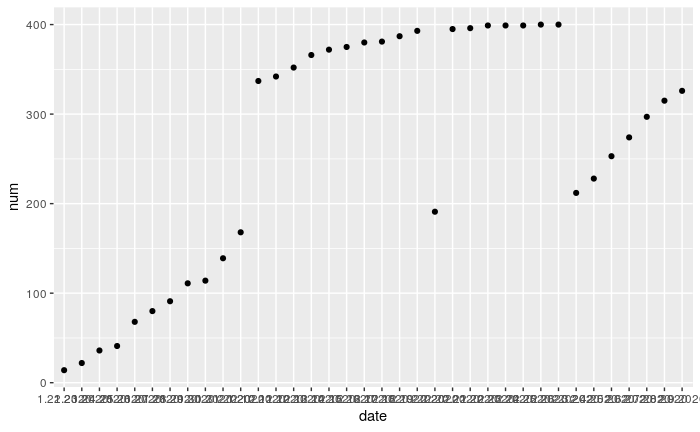

```r
df %>%
  filter(Province.State == "Beijing") %>%
  qplot(x = date, y = num, data = .)
```

Ми дізнались: 1) Наша колонка дати *не* сприймається як дата (R сприцмає її як категорійну змінну)! 2) Показано кумулятивні випадки — суму, а не лише зареєстровані в цей день. Будь ми не такі уважні, заявили б, що у світі півтора мільйони хворих, була б паніка згірше Медоборів і Санджар…

Як рахується кумулятивна сума? `x[i] + sum(x[:i-1])` Зробімо зворотню дію

Повернемось до цього пізніше, а поки подивимось дані на останню дату, в якій більше відбулось заражень

[figure not shown]

```r
?group_by

country_total_cases <- df %>%
  filter(date == "2020-02-26") %>%
  group_by(Country.Region) %>%
  summarise(n = sum(num)) %>%
  arrange(-n)

country_total_cases
```

| Country.Region | n |
| --- | --- |
| Mainland China | 78065 |
| South Korea | 1261 |
| Others | 705 |
| Italy | 453 |
| Japan | 189 |
| Iran | 139 |
| Singapore | 93 |
| Hong Kong | 91 |
| US | 59 |
| Thailand | 40 |

[output cut: 39 more lines]

Мнемонічне правило каже, що статистика починається там, де є хоч 30 спостережень. https://www.researchgate.net/post/What_is_the_rationale_behind_the_magic_number_30_in_statistics

Маємо 12 країн, де понад 30 випадків захворювання. Подивимось, яка смертність від вірусу цих країнах

```r
deadly <- read.csv("data/time_series_19-covid-Deaths.csv") %>%
    pivot_longer(cols = - c("Province.State", "Country.Region", "Lat", "Long"),
                 names_to = "date",
                 values_to = "deaths",
                 names_prefix = "X"
                 )

deadly$date <- as.POSIXct(deadly$date, format = "%m.%e.%Y")

deadly$deaths %>% sum()    # the same, it's aggregated
```

```
[1] 39160
```

```r
deadly_by_country <- deadly %>%
  filter(date == "2020-02-26") %>%
  group_by(Country.Region) %>%
  summarise(deaths = sum(deaths)) %>%
  arrange(-deaths) %>%
  filter(Country.Region != "Others")

deadly_by_country
```

| Country.Region | deaths |
| --- | --- |
| Mainland China | 2715 |
| Iran | 19 |
| Italy | 12 |
| South Korea | 12 |
| France | 2 |
| Hong Kong | 2 |
| Japan | 2 |
| Philippines | 1 |
| Taiwan | 1 |
| Afghanistan | 0 |

[output cut: 38 more lines]

```r
cases_deaths <- country_total_cases %>%
  filter(n > 30) %>%
  left_join(deadly_by_country) %>%
  fill(deaths) %>%
  mutate(death_rate = deaths / n * 100)
cases_deaths
```

| Country.Region | n | deaths | death_rate |
| --- | --- | --- | --- |
| Mainland China | 78065 | 2715 | 3.4778710 |
| South Korea | 1261 | 12 | 0.9516257 |
| Others | 705 | 12 | 1.7021277 |
| Italy | 453 | 12 | 2.6490066 |
| Japan | 189 | 2 | 1.0582011 |
| Iran | 139 | 19 | 13.6690647 |
| Singapore | 93 | 0 | 0.0000000 |
| Hong Kong | 91 | 2 | 2.1978022 |
| US | 59 | 0 | 0.0000000 |
| Thailand | 40 | 0 | 0.0000000 |

[output cut: 2 more lines]

```r
world_rate <- df %>%
  left_join(deadly) %>%
  filter(num > 0 & date == "2020-02-26") %>%
  summarise(deaths = sum(deaths), num = sum(num), deadly_rate = deaths / num * 100)
world_rate
```

| deaths | num | deadly_rate |
| --- | --- | --- |
| 2770 | 81397 | 3.403074 |

Довірчі інтервали? Ми маємо цифри, розраховані на невеликих сукупностях, і хочемо знати, які висновки з них можна зробити

```r
cases_deaths <- cases_deaths %>%
  mutate(error = qnorm(0.95) * death_rate / sqrt(n),
         min_conf_death_rate = death_rate - error,
         max_conf_death_rate = death_rate + error,
         ) %>%
  arrange(death_rate) %>%
  mutate(Country.Region = factor(.$Country.Region, levels = .$Country.Region))

cases_deaths
```

| Country.Region | n | deaths | death_rate | error | min_conf_death_rate | max_conf_death_rate |
| --- | --- | --- | --- | --- | --- | --- |
| Singapore | 93 | 0 | 0.0000000 | 0.00000000 | 0.0000000 | 0.0000000 |
| US | 59 | 0 | 0.0000000 | 0.00000000 | 0.0000000 | 0.0000000 |
| Thailand | 40 | 0 | 0.0000000 | 0.00000000 | 0.0000000 | 0.0000000 |
| Bahrain | 33 | 0 | 0.0000000 | 0.00000000 | 0.0000000 | 0.0000000 |
| South Korea | 1261 | 12 | 0.9516257 | 0.04407942 | 0.9075463 | 0.9957051 |
| Japan | 189 | 2 | 1.0582011 | 0.12660899 | 0.9315921 | 1.1848100 |
| Others | 705 | 12 | 1.7021277 | 0.10544472 | 1.5966829 | 1.8075724 |
| Hong Kong | 91 | 2 | 2.1978022 | 0.37896156 | 1.8188406 | 2.5767638 |
| Italy | 453 | 12 | 2.6490066 | 0.20472044 | 2.4442862 | 2.8537271 |
| Taiwan | 32 | 1 | 3.1250000 | 0.90866184 | 2.2163382 | 4.0336618 |

[output cut: 2 more lines]

Якщо довірчі інтервали перетинаються — різниці між показниками нема. Якщо ні — є статистично значуща різниця.

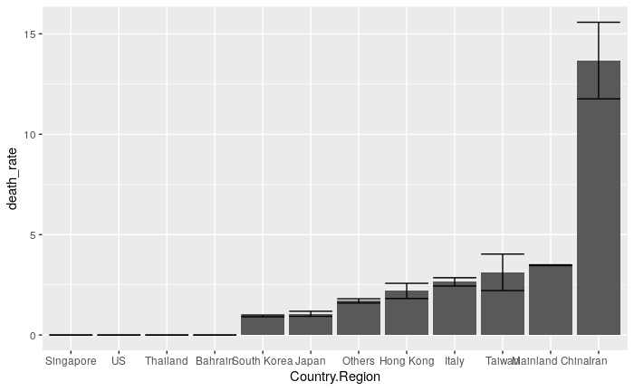

```r
ggplot(cases_deaths, aes(Country.Region, death_rate)) +
  geom_bar(stat = "identity") +
  geom_errorbar(aes(ymin = min_conf_death_rate, ymax = max_conf_death_rate))
```

Додамо стилю! І перевернемо графік

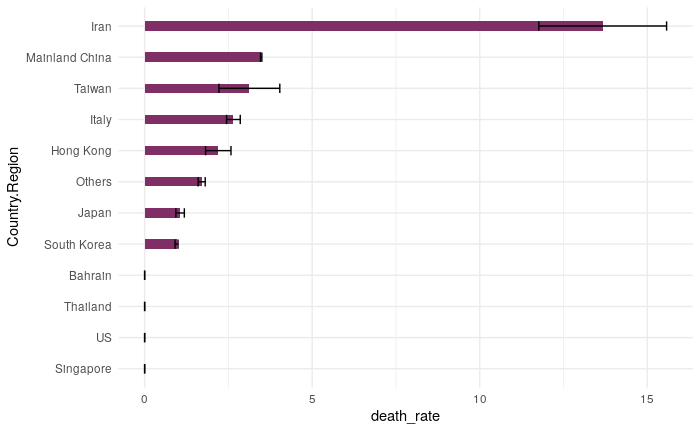

```r
ggplot(cases_deaths, aes(Country.Region, death_rate)) +
  geom_bar(stat = "identity", fill = "#802E66", width = 0.3) +
  geom_errorbar(aes(ymin = min_conf_death_rate, ymax = max_conf_death_rate),
                color = "black", width = 0.3) +
  coord_flip() +
  theme_minimal()
```

Це можна робити безкінечно: вибирати шрифти, писати зоголовки, підбирати відступи… Це набір параметрів, які можна знайти в [документації](https://ggplot2.tidyverse.org/reference/index.html)

**Наша метрика рівня смертності навмисне хибна! Яким чином?**

```r
diff(df$num)
```

```
   [1]      8      6     24     21     10     36     46     48     37     60     43     68     72     50     61     74     68     46     51
  [20]     30     29     21     24     16     12     11      9      4      1      1      1      0      0      0      0   -975      8     14
  [39]      5     27     12     11     20      3     25     29     23     21     16     25     21     23     18     11     11      5     10
  [58]     14      6      3      5      1      6      6      2      1      3      0      0      1      0   -394      3     18     30     18
  [77]     35     22     15     35     29     36     53     37     29     23     22     15      2     40     18     19     13     11      8
  [96]      7      7      2      2      5      7      5      1      2      1      0      0   -575      4      5      8     17     24     21
 [115]      4     17     19     24     15     20     15     11     10      9     15     11     11      6      5      7      2      4      2
 [134]      3      2      1      0      0      0      0      0      1      0   -294      2      0      2      3      7      5      5      2
 [153]      3     11     11      4      2      5      0      5     12      4      0      3      1      3      0      0      0      1      0
 [172]      0      0      0      0      0      0      0      0    -65      6     21     25     33     40     56     70     77     82     99
 [191]     97     93     88     82     75     64     61     36     28     18     42     22     20     33     22      6      6      3      1
 [210]      1      6      3      3      2      0  -1345      3     18      0     13     10      5      7     20      9     13     11     16
 [229]     12     11     18      4     11     12     15      5      7      0      4      9      2      1      4      2      1      1      3
 [248]      0      2      1      0   -251      2      0      1      1      2      2      0      3     17      0      9      8     12      6
 [267]      7     10      8     10     10     18      6      2      5      3      1      2      0      0      0      0      0      0      0
```

[output cut: 39 more lines]

[output not shown]

[output cut: 26 more lines]

# old, misc

[output not shown]

[output cut: 293 more lines]